# Exploração Homicídios

## Setup

```r
library(DBI)
library(usethis)
library(tidyverse)
library(cowplot)
devtools::load_all()
```

## Diagrama da base

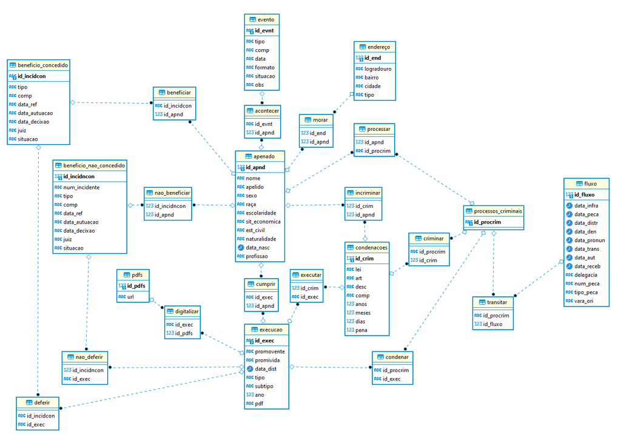

## Perguntas

### 1) Quantas pessoas foram condenadas por homicídio? Tanto o simples quanto o qualificado

O caminho para responder esta pergunta envolve recuperar todas as condenações, juntar com os apenados e filtrar para as condenações no art. 121, com exclusão daqueles na modalidade culposa

```r
con <- conectar() #base postgres
q <- "SELECT COUNT(DISTINCT id_apnd) FROM apenado
INNER JOIN incriminar
USING (id_apnd)
INNER JOIN condenacoes
USING (id_crim)
WHERE condenacoes.art = 'ART 121: Matar alguem:' AND
condenacoes.descr NOT LIKE '%Culposo%'"
dbGetQuery(con, q)
```

```
##   count
## 1 14058
```

Tá aí a resposta. 14.058 pessoas condenadas por homicídios que estão registradas no sistema de execução penal do PROJUDI. Apenas à título de contexto numérico, o ISP registra uma média de 5.000 vítimas de homicídio doloso a cada ano - claro que há diferenças entre os dois números. Um mesmo condenado por homicídio pode ter sido responsável por mais de um homicídio.

### 2) Mas quantos processos de execução penal por crime de homicídio houveram a cada ano?

Começando com o *query*, que envolve pegar os casos distintos de id de execução e ano, filtrado para homicídios:

```r
q <- "SELECT DISTINCT id_exec, ano FROM execucao
INNER JOIN executar
USING (id_exec)
INNER JOIN condenacoes
USING (id_crim)
WHERE condenacoes.art = 'ART 121: Matar alguem:' AND
condenacoes.descr NOT LIKE '%Culposo%'"
res <- dbGetQuery(con, q)
```

Ao todo, são 14.094 execuções penais por homicídios - 36 execuções a mais que o número de apenados por homicídio, o que mostra que há apenados com mais de uma execução.

Todavia, não necessariamente de pena privativa de liberdade. Há vários subtipos de execução, como pode ser vistos abaixo

```r
execs %>% select(tipo, subtipo) %>% distinct()
```

```
##                               tipo                            subtipo
## 1                 Execução da Pena        Pena Privativa de Liberdade
## 2  Execução de Medida de Segurança                         Internação
## 3  Execução de Medida de Segurança               Medidas de Segurança
## 4                 Execução da Pena                      Pena de Multa
## 5                 Execução da Pena        Pena Restritiva de Direitos
## 6  Execução de Medida de Segurança            Tratamento Ambulatorial
## 7                 Execução da Pena               Progressão de Regime
## 8                 Execução da Pena             Livramento condicional
## 9              Execução Provisória        Pena Privativa de Liberdade
## 10                Execução da Pena                   Crimes Hediondos
## 11                Execução da Pena Prestação de Serviços à Comunidade
## 12             Execução Provisória        Pena Restritiva de Direitos
## 13                Execução da Pena                            Remição
```

Como uma diferença de 36 perto de 14.000 não é lá tanta coisa, vamos fingir que está tudo bem. Plotando o número de processos de execução por ano, temos o seguinte:

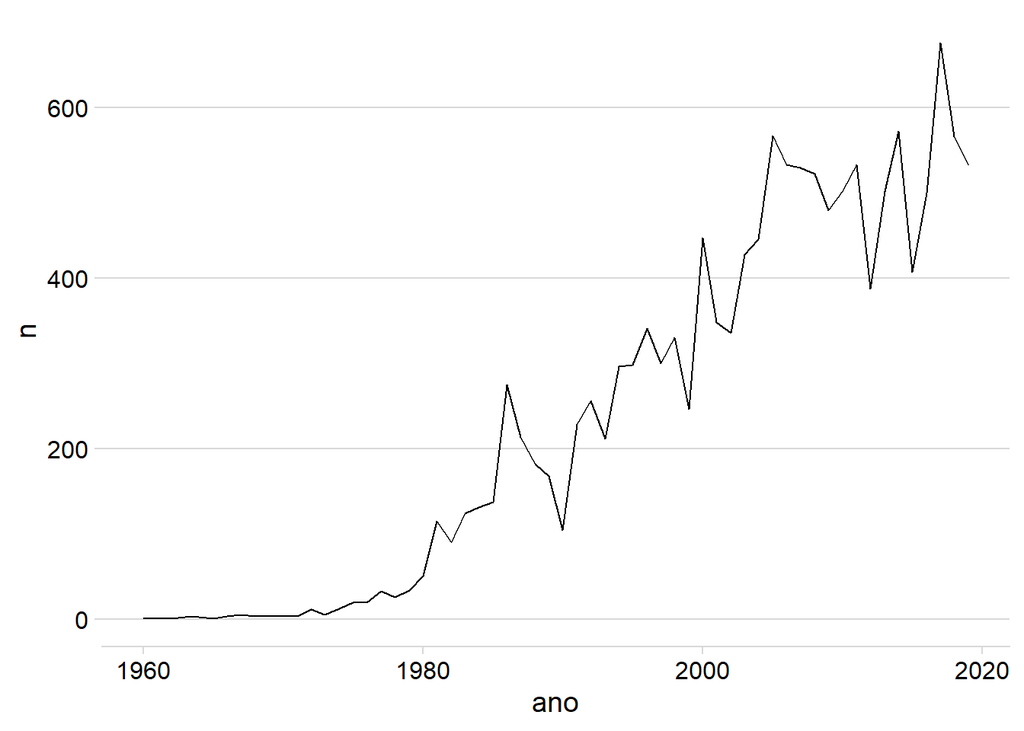

```r
exec_ano <- res %>% group_by(ano) %>%
  count()
ggplot(exec_ano, aes(y = n, x = ano)) +
  geom_line() +
  cowplot::theme_minimal_hgrid()
```

Uma clara tendência de crescimento após 1980. Vamos ver de quanto é

```r
exec_ano80_20 <- exec_ano %>% filter( ano >= 1980) %>% ungroup() %>%
  mutate(ano2 = ano - min(ano))
summary(lm(n ~ ano2, data = exec_ano80_20))
```

```
##
## Call:
## lm(formula = n ~ ano2, data = exec_ano80_20)
##
## Residuals:
##      Min       1Q   Median       3Q      Max
## -145.536  -29.576   -1.763   33.506  146.616
##
## Coefficients:
##             Estimate Std. Error t value Pr(>|t|)
## (Intercept)  90.0037    20.1608   4.464 6.96e-05 ***
## ano2         13.2152     0.8897  14.854  < 2e-16 ***
## ---
## Signif. codes:  0 '***' 0.001 '**' 0.01 '*' 0.05 '.' 0.1 ' ' 1
##
## Residual standard error: 64.95 on 38 degrees of freedom
## Multiple R-squared:  0.8531, Adjusted R-squared:  0.8492
## F-statistic: 220.6 on 1 and 38 DF,  p-value: < 2.2e-16
```

Em 1980, tínhamos um valor inicial de cerca de 90 condenados po homicídios. A cada ano, esse valor aumento, em média, 13,21.

### 3) E quantos destes 14.058 condenados por homicídios nós temos o processo digitalizado?

Parecido com o primeiro *query,* mas sem o *count* e com uns *joins* a mais

```r
q <- "SELECT DISTINCT id_apnd, nome, pdfs.url
FROM apenado
INNER JOIN incriminar
USING (id_apnd)
INNER JOIN condenacoes
USING (id_crim)
INNER JOIN cumprir
USING (id_apnd)
INNER JOIN execucao
USING (id_exec)
LEFT JOIN digitalizar
USING (id_exec)
LEFT JOIN pdfs
USING (id_pdfs)
WHERE condenacoes.art = 'ART 121: Matar alguem:' AND
condenacoes.descr NOT LIKE '%Culposo%'"
res <- dbGetQuery(con, q)
```

Seja lá por que diabos, desta vez o total 14.085 - mas ainda são 14.058 ids únicos de apenados. Ou seja, tem umas duplicatas aí. Desta vez, por causa da única variável adicionada: a url.

Feitas estas ressalvas, temos:

```r
nas <- res %>% mutate(tem_pdf = if_else(is.na(url), 0, 1)) %>%
  mutate(tem_pdf = as.logical(tem_pdf)) %>%
  group_by(tem_pdf) %>%
  count() %>%
  ungroup() %>%
  mutate(prop = (n/sum(n)) %>% round(2))
nas
```

```
## # A tibble: 2 x 3
##   tem_pdf     n  prop
##   <lgl>   <int> <dbl>
## 1 FALSE    6779  0.48
## 2 TRUE     7306  0.52
```

Uns 52% tem pdf, o resto não tem. Esses 52% dão cerca de 7.306 casos - “cerca de” por causa das imprecisões entre número de apenados e número de execuções digitalizadas.

### 4) Mas como esses processos digitalizados e não digitalizados se distribuem ao longo do ano?

A idéia aqui é ver mais ou menos quando o PROJUDI ficou mais robusto enquanto procedimento. Quanto entrou pra rotina.

```r
q <- "SELECT DISTINCT id_apnd, nome, pdfs.url, execucao.ano
FROM apenado
INNER JOIN incriminar
USING (id_apnd)
INNER JOIN condenacoes
USING (id_crim)
INNER JOIN cumprir
USING (id_apnd)
INNER JOIN execucao
USING (id_exec)
LEFT JOIN digitalizar
USING (id_exec)
LEFT JOIN pdfs
USING (id_pdfs)
WHERE condenacoes.art = 'ART 121: Matar alguem:' AND
condenacoes.descr NOT LIKE '%Culposo%'"
res <- dbGetQuery(con, q) %>%
  mutate(tem_pdf = if_else(is.na(url), 0, 1)) %>%
  mutate(tem_pdf = as.logical(tem_pdf)) %>%
  group_by(ano) %>%
  summarise(n_com = sum(tem_pdf),
            n_total = n(),
            n_sem = n_total - n_com) %>%
  ungroup() %>%
  mutate(prop_com = (n_com/n_total) %>% round(2),
         prop_sem = (n_sem/n_total) %>% round(2))
res
```

```
## # A tibble: 59 x 6
##      ano n_com n_total n_sem prop_com prop_sem
##    <dbl> <int>   <int> <int>    <dbl>    <dbl>
##  1  1960     0       1     1        0        1
##  2  1962     0       1     1        0        1
##  3  1963     0       2     2        0        1
##  4  1964     0       2     2        0        1
##  5  1965     0       1     1        0        1
##  6  1966     0       3     3        0        1
##  7  1967     0       5     5        0        1
##  8  1968     0       3     3        0        1
##  9  1969     0       3     3        0        1
## 10  1970     0       3     3        0        1
## # ... with 49 more rows
```

E vamos ao gráfico (com pdf está em azul, sem em vermelho)

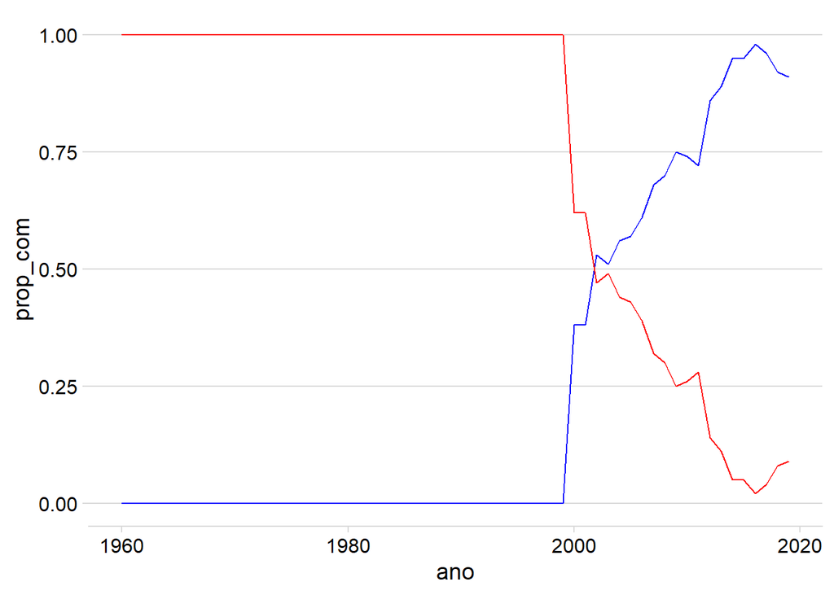

```r
ggplot(res, aes(y = prop_com, x = ano)) +
  geom_line(col = "blue") + geom_line(aes(y = prop_sem), inherit.aes = T, col = "red") +
  theme_minimal_hgrid()
```

A inversão se dá em 2002. Os primeiros processos de homicídios digitalizados, no todo ou em parte, datam de dois anos antes. A partir de 2012, são mais de 86% dos processos digitalizados - 89%, se contarmos a partir de 2013. Se regredirmos para abaixo de 2012, essa proporção cai e vai varia entre 70 e 74%, contando a partir de 2008 - depois cai para o patamar dos 60%.